# Wstęp do uczenia maszynowego

#### Interpretowalność

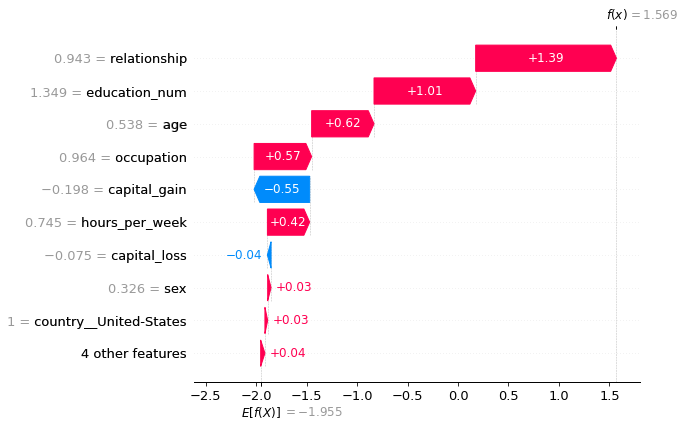

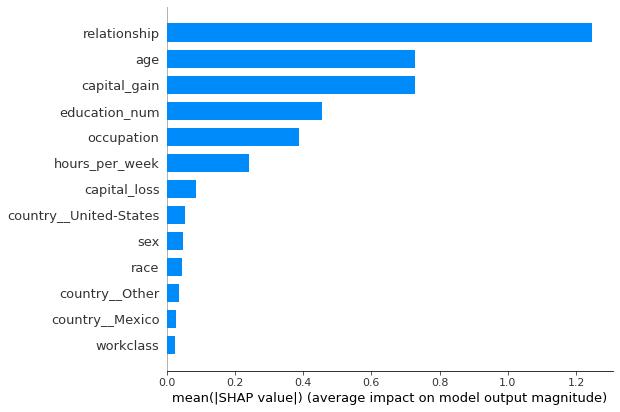

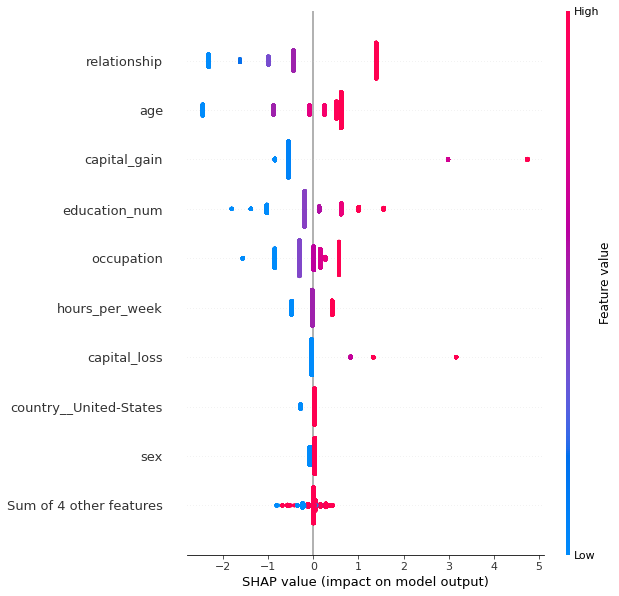

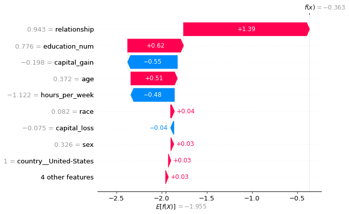

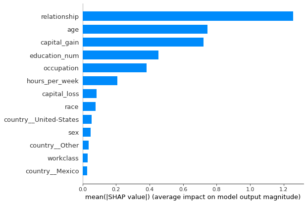

```python
shapley(lr, X_train, X_test)
```

```python
#Przypomnienie kodowania zmiennych na woe, aby lepiej odczytywać wykres waterfall
column_woe
```

```
{'workclass': workclass
 1   -1.289779
 2   -0.166381
 3    0.184412
 4    0.613741
 5    1.308614
 Name: WoE, dtype: float64,
 'occupation': occupation
 1   -3.334535
 2   -1.907806
 3   -0.802039
 4   -0.165099
 5    0.130278
 6    0.347478
 7    0.963702
 Name: WoE, dtype: float64,
 'relationship': relationship
 1   -3.004723
 2   -2.268540
 3   -1.598710
 4   -1.006359
 5    0.943267
 Name: WoE, dtype: float64,
 'race': race
 1   -0.834044
 2    0.082476
 Name: WoE, dtype: float64,
 'education_num': education_num
 1   -2.803907
 2   -2.175299
 3   -1.654555
 4   -0.419559
 5    0.053766
 6    0.775876
 7    1.348832
 8    2.160712
 Name: WoE, dtype: float64,
 'age': age
 1   -4.413059
 2   -1.879944
```

[output cut: 11 more lines]

```
 1   -0.074693
 2    1.010799
 3    1.639350
 4    3.941329
 Name: WoE, dtype: float64,
 'capital_gain': capital_gain
 1   -0.503579
 2   -0.197931
 3    3.409229
 4    5.204838
 Name: WoE, dtype: float64,
 'sex': sex
 1   -0.971650
 2    0.326009
 Name: WoE, dtype: float64}
```

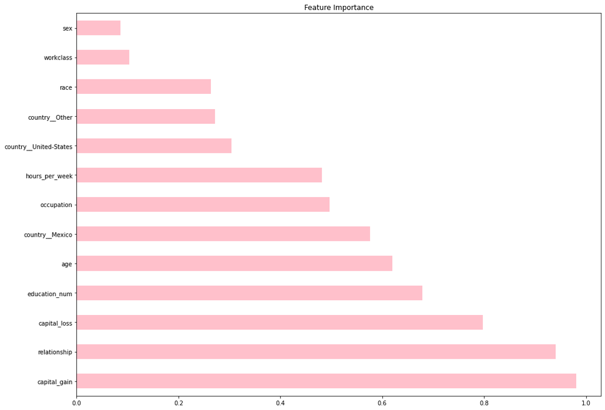

```python
importance = abs(lr.coef_[0])
feat_importances = pd.Series(importance, index=X_test.columns)
plt.figure(figsize=(16, 12))
feat_importances.nlargest(20).plot(kind='barh',title = 'Feature Importance', color = 'pink')
plt.show()
```

Dzięki użyciu shapley i feature importance, możemy wyróżnić kolumny `relationship`, `age`, `capital_gain` i `occupation` jako najważniejsze dla modelu regresji logistycznej. W rozbiciu predykcji na wykresach wodospadowych widać, że nasze wnioski z EDA potwierdzają się w procesie preykcji. Bycie w związku małżeńkskim (co odpowiada wartości 0.943) bardzo podwyższa szanse na większe zarobki. Z kolei przy godzinach pracy w tygodniu wartość -1.122 kodująca mnieszy godzinowy wymiar pracy wpływa na przeiwdywanie mniejszych zarobków.

### Gradient Boosting

#### Baseline

```python
gb = GradientBoostingClassifier()
gb.fit(X_train, y_train)
```

```
GradientBoostingClassifier()
```

```python
print_scores(gb, X_train, X_test, y_train)
```

```
ZBIÓR TRENINGOWY:
Accuracy score: 0.8553640739015681
Precision score: 0.7637571157495257
roc_auc score: 0.7712478320162617
-------------------------------
ZBIÓR TESTOWY:
Accuracy score: 0.8590732273254623
Precision score: 0.7697491576188693
roc_auc score: 0.7656257396424723
```

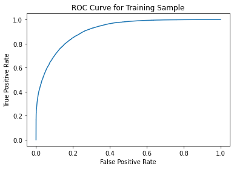

```
gini_test: 0.8244
```

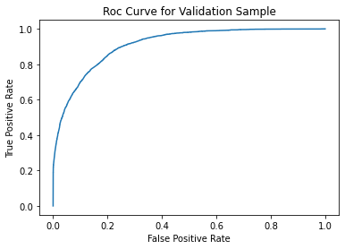

```
gini_val: 0.8219
```

```python
gini_train_val(gb, X_train, y_train, X_test, y_test)
```

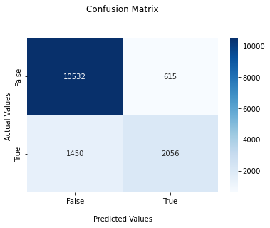

```python
show_confusion_matrix(y_test, gb.predict(X_test))
```

Dla zbioru bez kolumn `race` i `sex`:

```python
gb.fit(X_train2, y_train)
```

```
GradientBoostingClassifier()
```

```python
print_scores(gb, X_train2, X_test2, y_train)
```

```
ZBIÓR TRENINGOWY:
Accuracy score: 0.8554261760596181
Precision score: 0.7678112965340179
roc_auc score: 0.7694038542413068
-------------------------------
ZBIÓR TESTOWY:
Accuracy score: 0.8590732273254623
Precision score: 0.7746854746473504
roc_auc score: 0.7632795585376176
```

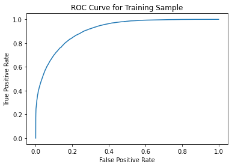

```
gini_test: 0.8224
```

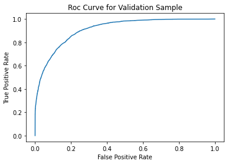

```
gini_val: 0.8220
```

```python
gini_train_val(gb, X_train2, y_train, X_test2, y_test)
```

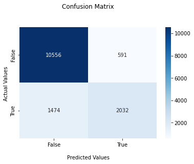

```python
show_confusion_matrix(y_test, gb.predict(X_test2))
```

Bazowy model z podbijaniem gradientu ma bardzo obiecujące wyniki.

#### Strojenie parametrów

```python
max_depth = [3,4,5,6]
loss = ['deviance', 'exponential']
learning_rate = [0, 0.05, 0.1]
n_estimators = [80, 90, 100, 110]
criterion = ['friedman_mse', 'squared_error', 'mse', 'mae']
param_grid = dict(max_depth=max_depth, n_estimators = n_estimators, criterion=criterion,
                loss=loss, learning_rate=learning_rate)
```

```python
gb = GradientBoostingClassifier()
random = RandomizedSearchCV(estimator=gb, param_distributions=param_grid, cv = 5, n_jobs=-1, random_state=110)

random_result = random.fit(X_train2, y_train)
print(f"Best score: {random_result.best_score_}")
print(f"Best parameters: {random_result.best_params_} ")
best_gb = random_result.best_estimator_
```

```
Best score: 0.8546809501630183
Best parameters: {'n_estimators': 100, 'max_depth': 5, 'loss': 'exponential', 'learning_rate': 0.05, 'criterion': 'friedman_mse'}
```

```python
best_gb.fit(X_train2, y_train)
```

```
GradientBoostingClassifier(learning_rate=0.05, loss='exponential', max_depth=5)
```

```python
print_scores(best_gb, X_train2, X_test2, y_train)
```

```
ZBIÓR TRENINGOWY:
Accuracy score: 0.8564819127464679
Precision score: 0.7796019900497513
roc_auc score: 0.7665868226290531
-------------------------------
ZBIÓR TESTOWY:
Accuracy score: 0.8585272640414932
Precision score: 0.7824201813165156
roc_auc score: 0.7583261129301927
```

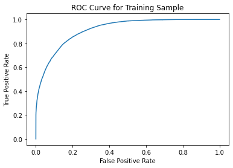

```
gini_test: 0.8283
```

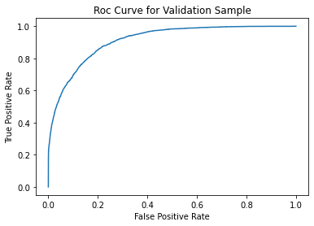

```
gini_val: 0.8222
```

```python
gini_train_val(best_gb, X_train2, y_train, X_test2, y_test)
```

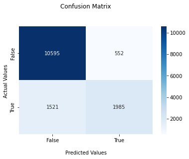

```python
show_confusion_matrix(y_test, best_gb.predict(X_test2))
```

#### Feature importance

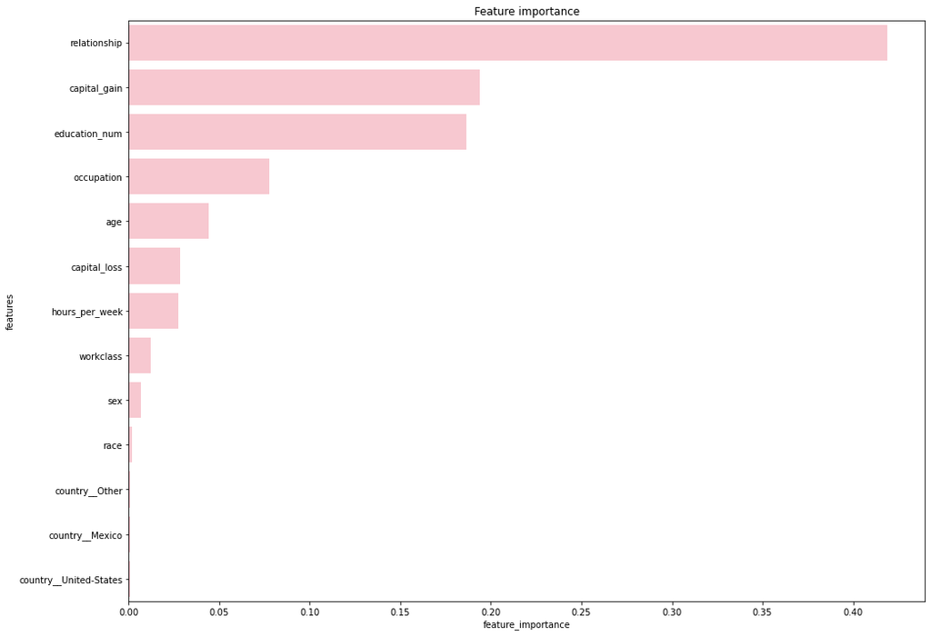

```python
feature_importance(best_gb)
```

Ważność kolumn układa się dosyć podobnie w przypadku lasów losowych.

### AdaBoost

#### Baseline

```python
abc = AdaBoostClassifier()
abc.fit(X_train, y_train)
```

```
AdaBoostClassifier()
```

```python
print_scores(abc, X_train, X_test, y_train)
```

```
ZBIÓR TRENINGOWY:
Accuracy score: 0.8513584847073435
Precision score: 0.756601056168987
roc_auc score: 0.7643104493915023
-------------------------------
ZBIÓR TESTOWY:
Accuracy score: 0.8556609568006551
Precision score: 0.7643481565944508
roc_auc score: 0.7589838941724222
```

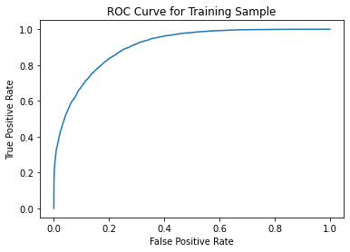

```
gini_test: 0.8124
```

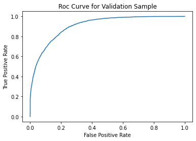

```
gini_val: 0.8148
```

```python
gini_train_val(abc, X_train, y_train, X_test, y_test)
```

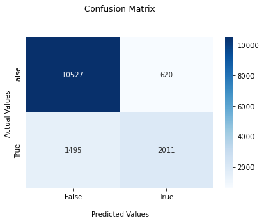

```python
show_confusion_matrix(y_test, abc.predict(X_test))
```

Dla zbioru bez kolumn `race` i `sex`:

```python
abc.fit(X_train2, y_train)
```

```
AdaBoostClassifier()
```

```python
print_scores(abc, X_train2, X_test2, y_train)
```

```
ZBIÓR TRENINGOWY:
Accuracy score: 0.8518553019717435
Precision score: 0.7553478054191095
roc_auc score: 0.7662747881819216
-------------------------------
ZBIÓR TESTOWY:
Accuracy score: 0.8566846379580974
Precision score: 0.7650829562594268
roc_auc score: 0.7614163567705973
```

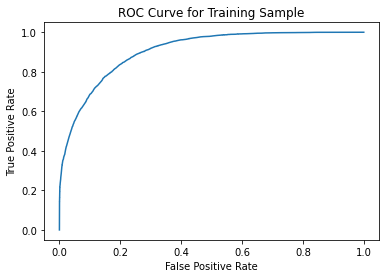

```
gini_test: 0.8126
```

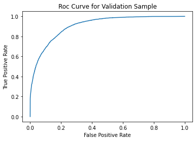

```
gini_val: 0.8164
```

```python
gini_train_val(abc, X_train2, y_train, X_test2, y_test)
```

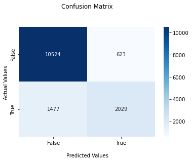

```python
show_confusion_matrix(y_test, abc.predict(X_test2))
```

#### Strojenie parametrów

```python
n_estimators = range(40, 100, 5)
learning_rate = [0.1, 0.2, 0.3, 0.4, 0.5, 0.6, 0.7, 0.8, 0.9]
param_grid = dict(n_estimators = n_estimators, learning_rate = learning_rate)
```

```python
abc = AdaBoostClassifier()
random = RandomizedSearchCV(estimator=abc, param_distributions=param_grid, cv = 5, n_jobs=-1, random_state=110)

random_result = random.fit(X_train, y_train)
print(f"Best score: {random_result.best_score_}")
print(f"Best parameters: {random_result.best_params_} ")
best_abc = random_result.best_estimator_
```

```
Best score: 0.8503337990995188
Best parameters: {'n_estimators': 95, 'learning_rate': 0.8}
```

```python
best_abc.fit(X_train2, y_train)
```

```
AdaBoostClassifier(learning_rate=0.8, n_estimators=95)
```

```python
print_scores(best_abc, X_train2, X_test2, y_train)
```

```
ZBIÓR TRENINGOWY:
Accuracy score: 0.8503337990995187
Precision score: 0.7527875119464797
roc_auc score: 0.76354515070558
-------------------------------
ZBIÓR TESTOWY:
Accuracy score: 0.8559339384426398
Precision score: 0.7651083238312428
roc_auc score: 0.759358829736369
```

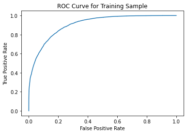

```
gini_test: 0.8133
```

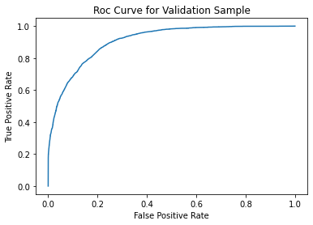

```
gini_val: 0.8169
```

```python
gini_train_val(best_abc, X_train2, y_train, X_test2, y_test)
```

Dobór parametrów delikatnie pogorszył wyniki. Dlatego lepiej zostać przy bazowym modelu.

```python
abc = AdaBoostClassifier()
abc.fit(X_train2, y_train)
```

```
AdaBoostClassifier()
```

#### Feature importance

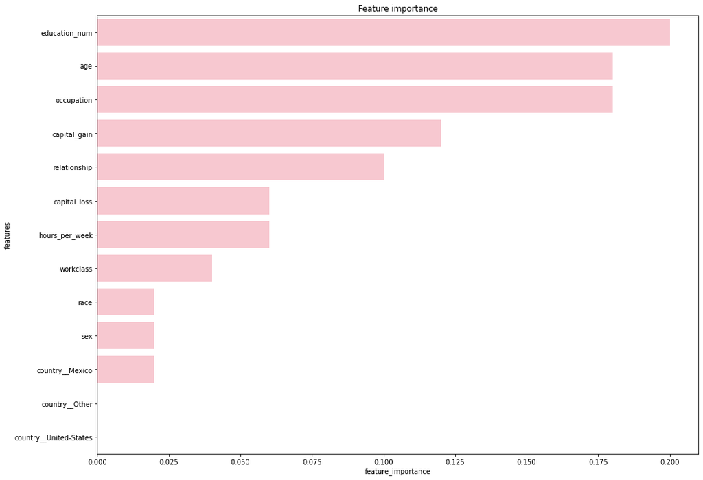

```python
feature_importance(abc)
```

Feature Importance w przypadku AdaBoost rozłożył się bardziej równomiernie. Tym razem najważniejszymi predyktorami są `education_num`, `age`, `occupation`.

### XGBoost

#### Baseline

```python
xgb = XGBClassifier(verbosity = 0)
xgb.fit(X_train, y_train)
```

```
XGBClassifier(base_score=0.5, booster='gbtree', colsample_bylevel=1,
              colsample_bynode=1, colsample_bytree=1, enable_categorical=False,
              gamma=0, gpu_id=-1, importance_type=None,
              interaction_constraints='', learning_rate=0.300000012,
              max_delta_step=0, max_depth=6, min_child_weight=1, missing=nan,
              monotone_constraints='()', n_estimators=100, n_jobs=8,
              num_parallel_tree=1, predictor='auto', random_state=0,
              reg_alpha=0, reg_lambda=1, scale_pos_weight=1, subsample=1,
              tree_method='exact', validate_parameters=1, verbosity=0)
```

```python
print_scores(xgb, X_train, X_test, y_train)
```

```
ZBIÓR TRENINGOWY:
Accuracy score: 0.8649899083993169
Precision score: 0.7857366771159875
roc_auc score: 0.7853166913514821
-------------------------------
ZBIÓR TESTOWY:
Accuracy score: 0.8607111171773698
Precision score: 0.7730152814014163
roc_auc score: 0.7684618983023681
```

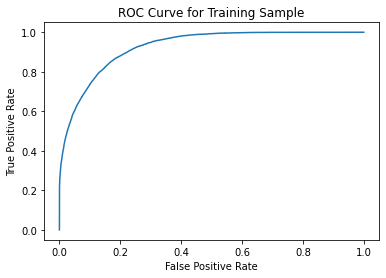

```
gini_test: 0.8523
```

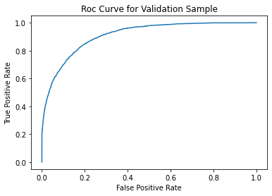

```
gini_val: 0.8188
```

```python
gini_train_val(xgb, X_train, y_train, X_test, y_test)
```

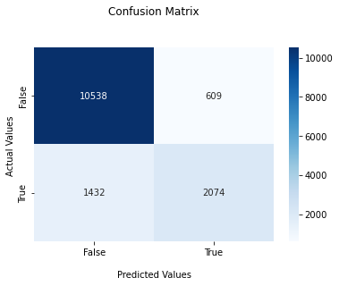

```python
show_confusion_matrix(y_test, xgb.predict(X_test))
```

```python
xgb.fit(X_train2, y_train)
```

```
XGBClassifier(base_score=0.5, booster='gbtree', colsample_bylevel=1,
              colsample_bynode=1, colsample_bytree=1, enable_categorical=False,
              gamma=0, gpu_id=-1, importance_type=None,
              interaction_constraints='', learning_rate=0.300000012,
              max_delta_step=0, max_depth=6, min_child_weight=1, missing=nan,
              monotone_constraints='()', n_estimators=100, n_jobs=6,
              num_parallel_tree=1, predictor='auto', random_state=0,
              reg_alpha=0, reg_lambda=1, scale_pos_weight=1, subsample=1,
              tree_method='exact', validate_parameters=1, verbosity=0)
```

```python
print_scores(xgb, X_train2, X_test2, y_train)
```

```
ZBIÓR TRENINGOWY:
Accuracy score: 0.8620090048129172
Precision score: 0.7797037503939489
roc_auc score: 0.7806109373240537
-------------------------------
ZBIÓR TESTOWY:
Accuracy score: 0.8591414727359585
Precision score: 0.7690298507462686
roc_auc score: 0.7661593824906192
```

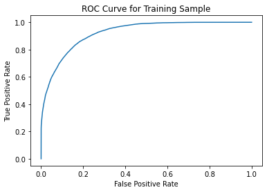

```
gini_test: 0.8452
```

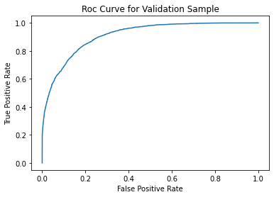

```
gini_val: 0.8187
```

```python
gini_train_val(xgb, X_train2, y_train, X_test2, y_test)
```

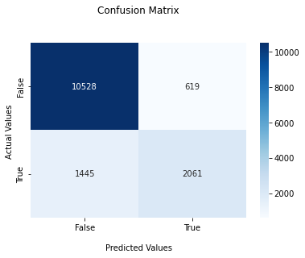

```python
show_confusion_matrix(y_test, xgb.predict(X_test2))
```

#### Strojenie parametrów

```python
learning_rate=[0.05, 0.1, 0.15, 0.2]
max_depth=[3,4,5,6,7,8,9,10]
min_child_weight=[2,3,4,5,7,10,150]
n_estimators=range(80, 120, 5)
param_grid = dict(learning_rate=learning_rate, max_depth=max_depth,
                  min_child_weight=min_child_weight, n_estimators=n_estimators)
```

```python
xgb = XGBClassifier()
random = RandomizedSearchCV(estimator=xgb, param_distributions=param_grid, cv = 5, n_jobs=-1, random_state=110)

random_result = random.fit(X_train2, y_train)
print(f"Best score: {random_result.best_score_}")
print(f"Best parameters: {random_result.best_params_} ")
best_xgb = random_result.best_estimator_
```

```
Best score: 0.8541220307405682
Best parameters: {'n_estimators': 95, 'min_child_weight': 5, 'max_depth': 7, 'learning_rate': 0.05}
```

```python
best_xgb.fit(X_train2, y_train)
```

```
XGBClassifier(base_score=0.5, booster='gbtree', colsample_bylevel=1,
              colsample_bynode=1, colsample_bytree=1, enable_categorical=False,
              gamma=0, gpu_id=-1, importance_type=None,
              interaction_constraints='', learning_rate=0.05, max_delta_step=0,
              max_depth=7, min_child_weight=5, missing=nan,
              monotone_constraints='()', n_estimators=95, n_jobs=8,
              num_parallel_tree=1, predictor='auto', random_state=0,
              reg_alpha=0, reg_lambda=1, scale_pos_weight=1, subsample=1,
              tree_method='exact', validate_parameters=1, verbosity=None)
```

```python
print_scores(best_xgb, X_train2, X_test2, y_train)
```

```
ZBIÓR TRENINGOWY:
Accuracy score: 0.8571960875640429
Precision score: 0.7796079723274584
roc_auc score: 0.7684024578261874
-------------------------------
ZBIÓR TESTOWY:
Accuracy score: 0.8590732273254623
Precision score: 0.7815552950371238
roc_auc score: 0.7601513170644784
```

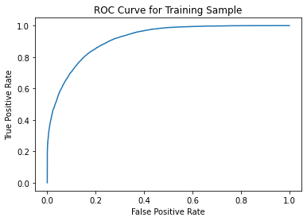

```
gini_test: 0.8295
```

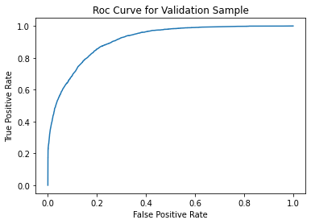

```
gini_val: 0.8217
```

```python
gini_train_val(best_xgb, X_train2, y_train, X_test2, y_test)
```

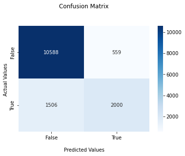

```python
show_confusion_matrix(y_test, best_xgb.predict(X_test2))
```

Po tuningu wyniki dla xgb nieróżnią się wiele, gini się zrównoważyło, ale ogólnie nie jest oczywistym stwierdzenie, że tuning pomógł.

#### Feature importance

```python
explainer = shap.TreeExplainer(best_xgb, X_train)
shap_values = explainer(X_train)
```

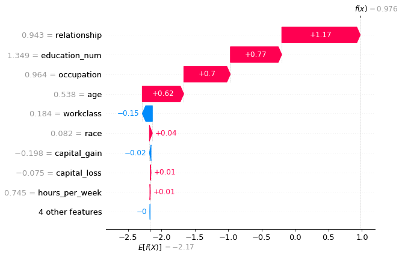

```python
shap.plots.waterfall(shap_values[0])
```

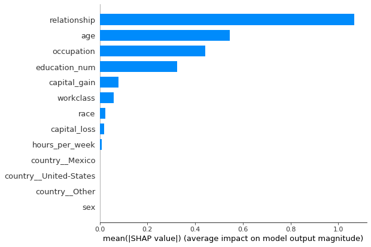

```python
shap.summary_plot(shap_values, X_train, plot_type = 'bar')
```

```python
shap_values = explainer(X_test)
```

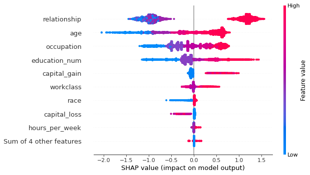

```python
shap.plots.beeswarm(shap_values)
```

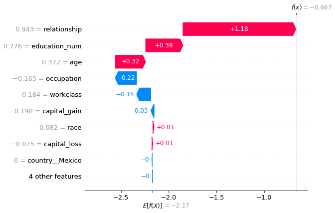

```python
shap.plots.waterfall(shap_values[0])
```

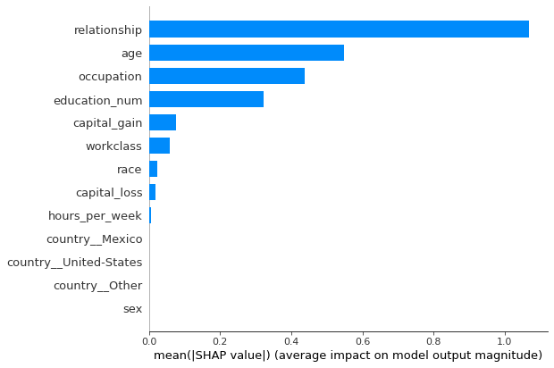

```python
shap.summary_plot(shap_values, X_train, plot_type = 'bar')
```

Po przenalizowaniu wyresów shapley, break down value i feature importance widać, że dla modelu xgboosta największe znaczenie miały zmienne `relationship`, `age` i `occupation`. W prawie wszystich kolumnach większa wartość oznacza wpływ pozytywny na predykcję. Na wykresach wodospadowych widać, że wartości wpływają podobnie na wartość przewidywaną jak w modelu regresji logistycznej.

### Trenowanie z użyciem TPOTClassifier

Sprawdźmy najpierw, który model zostanie wybrany jako najlepszy przez `TPOTClassifier`.

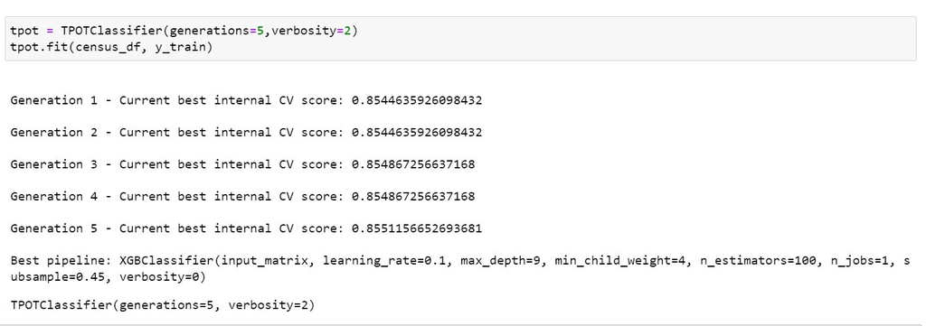

Zastosowanie TPOT wskazało, że najlepiej użyć klasyfikatora XGBoost z następującymi parametrami: learning_rate=0.1, max_depth=9, min_child_weight=4, n_estimators=100, n_jobs=1, subsample=0.45, verbosity=0. Sprawdźmy jak prezentują się nasze metryki dla tego modelu.

```python
tpot_xgb = XGBClassifier(learning_rate=0.1, max_depth=9, min_child_weight=4,
                         n_estimators=100, n_jobs=1, subsample=0.45, verbosity=0)
tpot_xgb.fit(X_train2, y_train)
```

```
XGBClassifier(base_score=0.5, booster='gbtree', colsample_bylevel=1,
              colsample_bynode=1, colsample_bytree=1, enable_categorical=False,
              gamma=0, gpu_id=-1, importance_type=None,
              interaction_constraints='', learning_rate=0.1, max_delta_step=0,
              max_depth=9, min_child_weight=4, missing=nan,
              monotone_constraints='()', n_estimators=100, n_jobs=1,
              num_parallel_tree=1, predictor='auto', random_state=0,
              reg_alpha=0, reg_lambda=1, scale_pos_weight=1, subsample=0.45,
              tree_method='exact', validate_parameters=1, verbosity=0)
```

```python
print_scores(tpot_xgb, X_train2, X_test2, y_train)
```

```
ZBIÓR TRENINGOWY:
Accuracy score: 0.8620711069709672
Precision score: 0.7846153846153846
roc_auc score: 0.7784736935668171
-------------------------------
ZBIÓR TESTOWY:
Accuracy score: 0.858390773220501
Precision score: 0.7692886714339481
roc_auc score: 0.7640040979103553
```

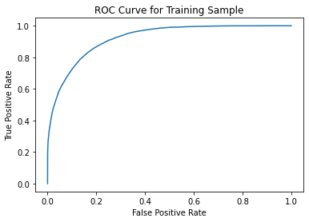

```
gini_test: 0.8401
```

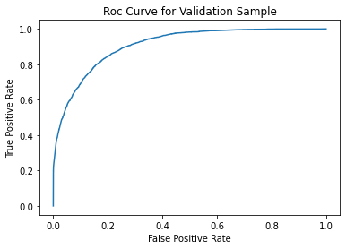

```
gini_val: 0.8181
```

```python
gini_train_val(tpot_xgb, X_train2, y_train, X_test2, y_test)
```

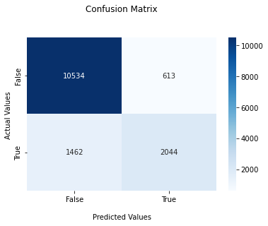

```python
show_confusion_matrix(y_test, tpot_xgb.predict(X_test2))
```

Modele xgboost, zarówno strojony za pomocą randomsearch, jak i wytrenowany przez TPOT mają bardzo zbliżone wyniki. Wydaje się jednak, że pierwszy model, ten znaleziony przez nas, ma lepsze parametry na zbiorze testowym.

## Podsumowanie

Sposród wszystkich modeli, które stworzyliśmy, uznajemy że najlepsza jest regresja logstyczna. W przypadku naszego zbioru danych wartości metryk były bardzo zbliżone. Być może w przypadku regresji logistycznej wyniki były słabsze, ale minimalnie i nie powinny mieć aż tak dużego znaczenia w predykcji, ale za to ten model wydaje nam się najłatwiejszy, jeśli chodzi o interpretację. Sam model nie jest blackboxem, a dodatkowo dzięki feature importance, break down i shapley values z łatwością jesteśmy wskazać jakie zmienne są najważniejsze dla modelu i jak wpływają na wynik predykcji.

```python
#do zapisywania wymagan
#!pip freeze > requirements.txt
```